# 5205_Project_Code

#### iii.Version 7

```r
terms(topic6_v7, 15)
```

```
##       Topic 1    Topic 2     Topic 3   Topic 4     Topic 5   Topic 6
##  [1,] "good"     "people"    "good"    "account"   "log"     "like"
##  [2,] "great"    "log"       "great"   "people"    "just"    "still"
##  [3,] "matches"  "just"      "get"     "something" "nice"    "get"
##  [4,] "message"  "one"       "like"    "went"      "matches" "even"
##  [5,] "facebook" "nice"      "match"   "wrong"     "people"  "fix"
##  [6,] "just"     "time"      "update"  "time"      "love"    "login"
##  [7,] "problem"  "get"       "matches" "great"     "let"     "now"
##  [8,] "people"   "new"       "fake"    "use"       "got"     "match"
##  [9,] "one"      "use"       "now"     "try"       "awesome" "people"
## [10,] "even"     "cool"      "nice"    "like"      "new"     "just"
## [11,] "use"      "good"      "love"    "matches"   "like"    "can"
## [12,] "please"   "update"    "log"     "works"     "now"     "good"
## [13,] "love"     "can"       "dating"  "back"      "cool"    "problem"
## [14,] "can"      "something" "new"     "new"       "keeps"   "fake"
## [15,] "see"      "keeps"     "one"     "work"      "wrong"   "many"
```

##### Visualize Topic Model for Version 7:

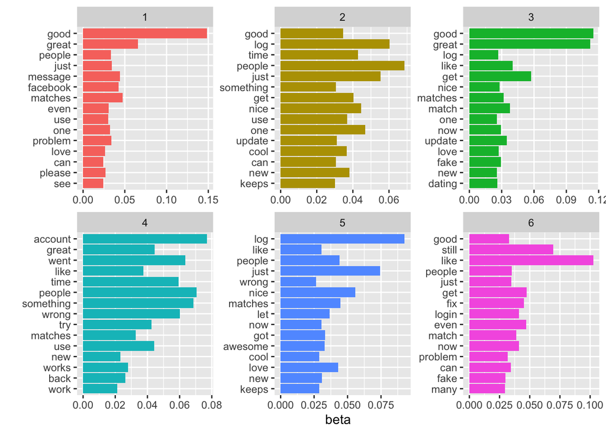

```r
library(tidytext); library(dplyr); library(ggplot2); library(tidyr)
topic6_v7 %>%
  tidy(matrix='beta')%>%
  group_by(topic)%>%
  top_n(n = 15,wt=beta)%>%
  ungroup()%>%
  ggplot(aes(x=reorder(term,beta),y=beta,fill=factor(topic)))+
  geom_bar(position='dodge', stat='identity')+
  facet_wrap(~topic, scales = 'free')+
  coord_flip()+guides(fill=F)+xlab('')
```

##### Interpret Topic Model for Version 7:

Topic 4: This topic seems to be about users experiencing problems with their account, such as login issues or problems with their profile.

Topic 5: This topic is focused on people’s overall experiences with the app, including their interactions with other users, and their general impression of the app. Words like “like” and “just” appear frequently.

Topic 6: This topic appears to be about users who have encountered fake profiles or other fraudulent activity on the app. Words like “fake” and “like” appear frequently, indicating that users may be frustrated or suspicious of some users they have encountered.